# Sesion 2

# ESTADISTICA PARA EL ANALISIS POLITICO II

- Profesor: [Dr. José Manuel Magallanes, Ph.D.](http://www.pucp.edu.pe/profesor/jose-manuel-magallanes/)
  - Profesor del Departamento de Ciencias Sociales, Sección de Ciencia Política y Gobierno.
  - [Oficina 105](https://goo.gl/maps/xuGeG6o9di1i1y5m6) - Edificio CISEPA / ECONOMIA / CCSS
  - Telefono: (51) 1 - 6262000 anexo 4302
  - Correo Electrónico: jmagallanes@pucp.edu.pe

## Regresión Lineal Multivariada (II)

## Regresión Lineal

La regresión es una técnica donde hay que definir una variable dependiente y una o más independientes. Las independientes pueden tener rol predictor, dependiendo del diseño de investigación, pero cumple siempre un rol explicativo; así, la regresión quiere informar cuánto una variable (*independiente*) puede explicar la variación de otra (*dependiente*), de ahí que es una técnica para probar hipótesis direccionales o asimétricas (las correlaciones tiene hipótesis no direccionales o simétricas).

La regresión lineal busca proponer un modelo, es decir una ecuación, que recoja como una variable explicaría a otra. La regresión lineal es también conocida como la **Regresión Gaussiana**, la cual es aplicable sólo cuando la variable dependiente (la **Y**) es *numérica*, *contínua*, y *no acotada*.

## Caso de Estudio

Profesores de la [Universidad de los Andes](https://dialnet.unirioja.es/servlet/articulo?codigo=2923538) decidieron estudiar cómo la distribución de fondos públicos fue afectada por factores políticos durante el primer periodo del Presidente Uribe (2002-2006). Las hipótesis que se plantean son:

- H1: la asignación presupuestal en infraestructura vial en Colombia responde a los criterios técnicos y económicos determinados en el Plan Nacional de Desarrollo y otros documentos de carácter técnico elaborados por el gobierno.
- H2: la asignación presupuestal en infraestructura vial en Colombia responde a negociaciones bilaterales entre el ejecutivo y el legislativo basadas en necesidades políticas y electorales de corto plazo.
- H3: la asignación presupuestal en infraestructura vial en Colombia responde al esfuerzo del gobierno por fortalecer su base social de apoyo local a través de los Consejos Comunales de Gobierno.

Para ello, organizaron estos datos:

[interactive chart not shown]

Luego de leer el artículo:

1. ¿Cómo decidieron los autores operacionalizar las variables independientes y la dependiente?
2. ¿Qué función cumplen las variables de control?
3. ¿Para que les sirvió la regresión?
4. ¿Hicieron una regresión por cada hipotesis?
5. ¿Se probaron todas las hipótesis?

Pasemos a usar los datos en R:

## Preparación de los datos

Veamos los datos del artículo [¿Pavimentando Con Votos](http://www.scielo.org.co/scielo.php?script=sci_arttext&pid=S0121-56122008000200002). Los datos tienen estas características una vez cargados en R:

```r
#carga de data
linkToData='https://docs.google.com/spreadsheets/d/e/2PACX-1vSRpCC8gKIxMxpK0wjgLcl-GQWdw6sAeB16Sixkq6kZXeTfMS8_n70twbEbQ2tMcGp8tm-6x8qf8ieo/pub?gid=234740779&single=true&output=csv'
pavi=read.csv(linkToData)
str(pavi)
```

```
## 'data.frame':    1096 obs. of  9 variables:
##  $ municipio       : chr  "m1" "m2" "m3" "m4" ...
##  $ apropiaciondolar: num  102.17 4.19 1.59 0 0 ...
##  $ consejocomunal  : int  0 0 0 0 0 0 0 0 0 0 ...
##  $ ejecucion       : int  0 0 0 0 0 0 0 0 0 0 ...
##  $ uribista        : int  0 1 1 1 1 1 1 1 1 NA ...
##  $ pctopo          : num  14.82 14.51 15.08 6.15 47.31 ...
##  $ priorizado      : int  0 1 0 0 0 0 0 0 1 0 ...
##  $ poblacioncienmil: num  20.9155 0.2406 0.0398 0.0558 0.2723 ...
##  $ nbi             : num  12.2 33.8 28.5 33.1 27.1 ...
```

Nótese que debemos tener claro cuáles son categóricas:

```r
seleccion=c("consejocomunal","ejecucion","uribista","priorizado")
pavi[,seleccion]=lapply(pavi[,seleccion],as.factor)
```

Veamos una hipotesis: ‘*el Beneficio recibido*’ en un municipio ha sido afectado por ‘*el porcentaje de votos recibidos por los candidatos de la oposición a Uribe a la camara de representantes*’, controlando por ‘*tamaño de población*’, la cual se representa en R así:

```r
modelo1=formula(apropiaciondolar~pctopo+poblacioncienmil)
```

Veamos el resultado:

```r
library(stargazer)
reg1=lm(modelo1,data=pavi)
stargazer(reg1,type = "html",intercept.bottom = FALSE)
```

|  | *Dependent variable:* |
| --- | --- |
|  | apropiaciondolar |
| Constant | 8.374*** |
|  | (0.685) |
| pctopo | -0.035* |
|  | (0.018) |
| poblacioncienmil | 2.199*** |
|  | (0.192) |
| Observations | 1,089 |
| R<sup>2</sup> | 0.111 |
| Adjusted R<sup>2</sup> | 0.109 |
| Residual Std. Error | 15.177 (df = 1086) |
| F Statistic | 67.741*** (df = 2; 1086) |
| *Note:* | p<0.1; p<0.05; p<0.01 |

Al probar esta hipótesis vemos, **primero** que *pctopo* tiene *efecto significativo* al **0.1** (indicado por el asterisco); **segundo**, que ese efecto es *inverso*, pues el coeficiente calculado es negativo; y **tercero** que la *magnitud* de ese efecto es -0.035, lo que indica cuanto varía *apropiaciondolar* en promedio cuando *pctopo* se incremente en una unidad, controlando por *poblacioncienmil*.

Esto es información suficiente para representar esa relación con una ecuación:

$$apropiaciondolar = 8.3741547 + -0.0349535 \cdot pctopo + 2.1986218\cdot poblacioncienmil + \epsilon$$

```r
modelo2=formula(apropiaciondolar~pctopo+consejocomunal+poblacioncienmil)
```

Esta nueva hipótesis desea evaluar si la visita de Uribe a un Consejo Comunal influye en la asignación de presupuesto. Veamos qué sale:

```r
reg2=lm(modelo2,data=pavi)
stargazer(reg2,type = "html",intercept.bottom = FALSE)
```

|  | *Dependent variable:* |
| --- | --- |
|  | apropiaciondolar |
| Constant | 7.697*** |
|  | (0.681) |
| pctopo | -0.033* |
|  | (0.018) |
| consejocomunal1 | 12.723*** |
|  | (2.015) |
| poblacioncienmil | 1.976*** |
|  | (0.192) |
| Observations | 1,089 |
| R<sup>2</sup> | 0.142 |
| Adjusted R<sup>2</sup> | 0.140 |
| Residual Std. Error | 14.912 (df = 1085) |
| F Statistic | 60.059*** (df = 3; 1085) |
| *Note:* | p<0.1; p<0.05; p<0.01 |

Nótese la lectura del efecto cuando la variable independiente es categórica (o *factor*). Primero, nota que *R* indica el valor *1* con el nombre de la variable: eso indica que el valor **0** (cuando el consejo comunal de ese municipio NO fue visitado) es la *categoría de referencia*; es decir, el coeficiente nos indica cuanto se modifica el valor promedio de la dependiente cuando se pasa de 0 a 1. Si la variable independiente es politómica (no ordinal), aparecerá cada categoría menos la de referencia, y el efecto siempre se debe interpretar como el efecto de la variable mostrada versus la de referencia.

Esto es información suficiente para representar esa relación con una ecuación:

$$apropiaciondolar = 7.6966432 + -0.0325495 \cdot pctopo + 12.7227555 \cdot consejocomunal + 1.9759204\cdot poblacioncienmil + \epsilon$$

En ambos modelos, el $\epsilon$ no tiene coeficiente, representamos su variación usando el error típico de los residuos o *residual standard error* (RSE). Nótese que éste ha variado de un modelo ha otro, ahora tenemos un RSE menor. Aquí vale la pena preguntarse si esta disminución del error es significativa, obteniendo:

```r
tanova=anova(reg1,reg2)
stargazer(tanova,type = 'html',summary = F,title = "Table de Análisis de Varianza")
```

**Table de Análisis de Varianza**

|  | Res.Df | RSS | Df | Sum of Sq | F | Pr(> F) |
| --- | --- | --- | --- | --- | --- | --- |
| 1 | 1,086 | 250,145.600 |  |  |  |  |
| 2 | 1,085 | 241,283.900 | 1 | 8,861.675 | 39.849 | 0 |

La comparación de modelos usando la tabla de análisis de varianza (anova) propone como hipótesis nula que los modelos no difieren (no se ha reducido el error al pasar de un modelo a otro). Como la comparación es *significativa* (vea el **Pr(>F)**), rechazamos igualdad de modelos: el modelo 2 sí reduce el error al incluir una variable más.

## Diagnósticos de la Regresión

Para que se considere que el modelo de regresión elegido es el adecuado, debemos verificar algunos requisitos a posteriori:

**1. Linealidad**:

Se asume relación lineal entre Y y Xs:

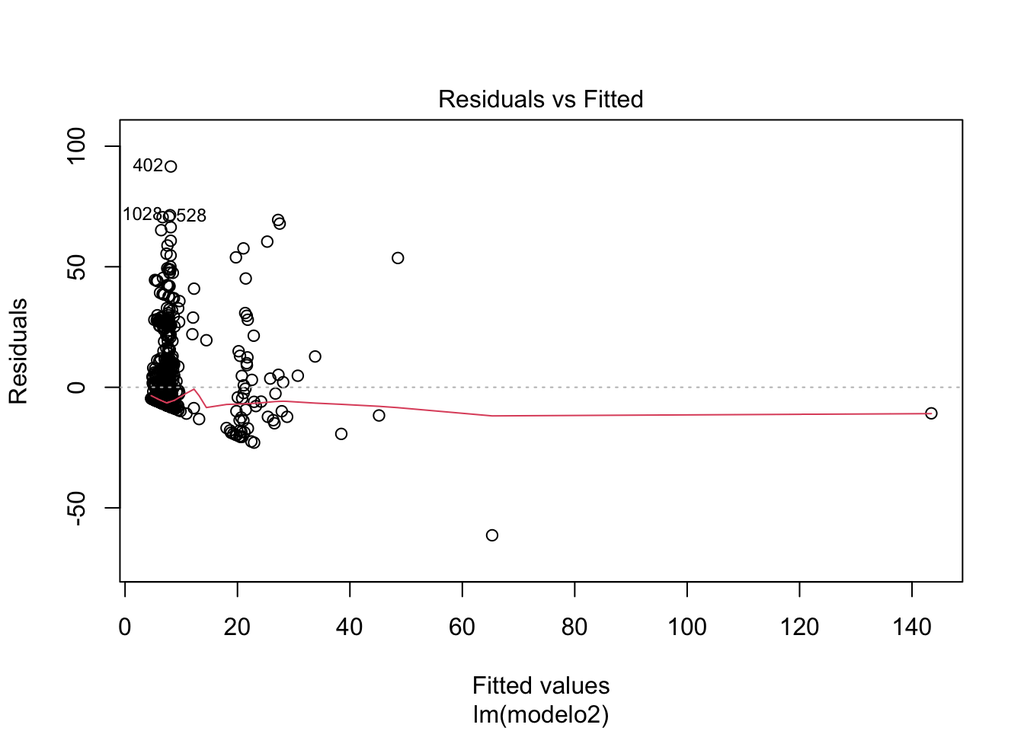

```r
# linea roja debe tender a horizontal
plot(reg2, 1)
```

**2. Homocedasticidad**

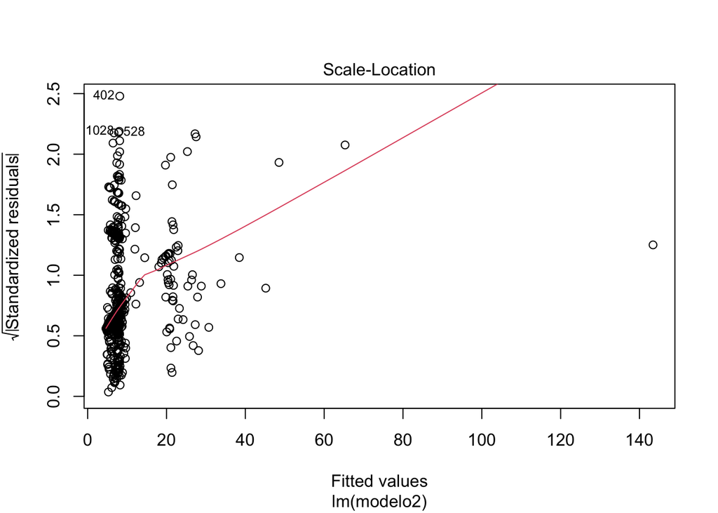

```r
# linea roja debe tender a horizontal
plot(reg2, 3)
```

También podemos utilizar el test de Breusch-Pagan:

```r
library(lmtest)
# null: modelo homocedastico
bptest(reg2)
```

```
##
##  studentized Breusch-Pagan test
##
## data:  reg2
## BP = 36.434, df = 3, p-value = 6.061e-08
```

La probabilidad de homocedasticidad es muy baja (p-value menor a 0.05), de ahi que se rechaza que el modelo muestre homocedasticidad.

**3. Normalidad de los residuos**

Los residuos, la diferencia entre *apropiaciondolar* y $\hat{apropiaciondolar}$, deben distribuirse de manera normal:

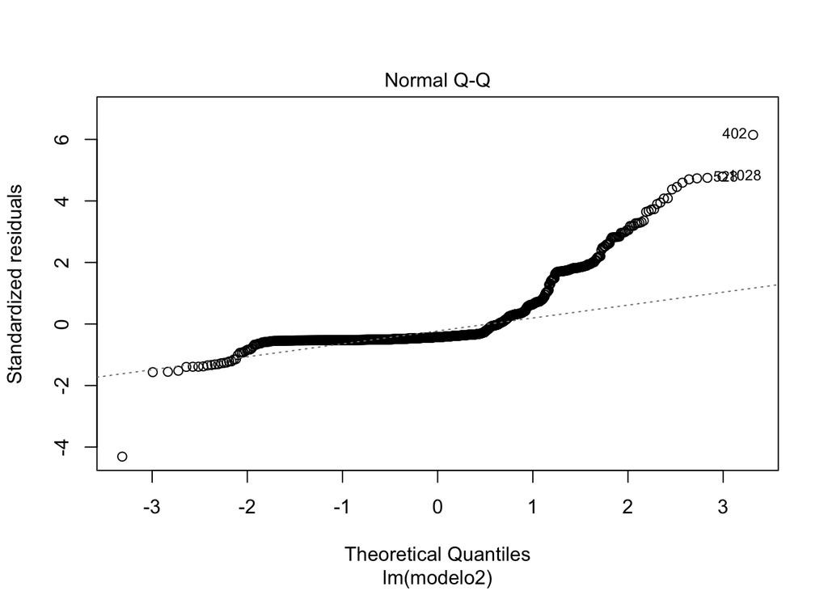

```r
# puntos cerca a la diagonal
plot(reg2, 2)
```

Podemos aplicar el test de Shapiro a los residuos:

```r
shapiro.test(reg2$residuals)
```

```
##
##  Shapiro-Wilk normality test
##
## data:  reg2$residuals
## W = 0.66729, p-value < 2.2e-16
```

**4. No multicolinelidad**

Si los predictores tienen una correlación muy alta entre sí, hay multicolinealidad, lo cual no es deseable:

```r
library(DescTools)
VIF(reg2) # > 5 es problematico
```

```
##           pctopo   consejocomunal poblacioncienmil
##         1.000465         1.035584         1.035113
```

**5. Valores influyentes**:

Hay casos particulares, que tienen la capacidad de trastocar lo que el modelo representa. A veces detectándolos y suprimiéndolos, podemos ver un mejor modelo:

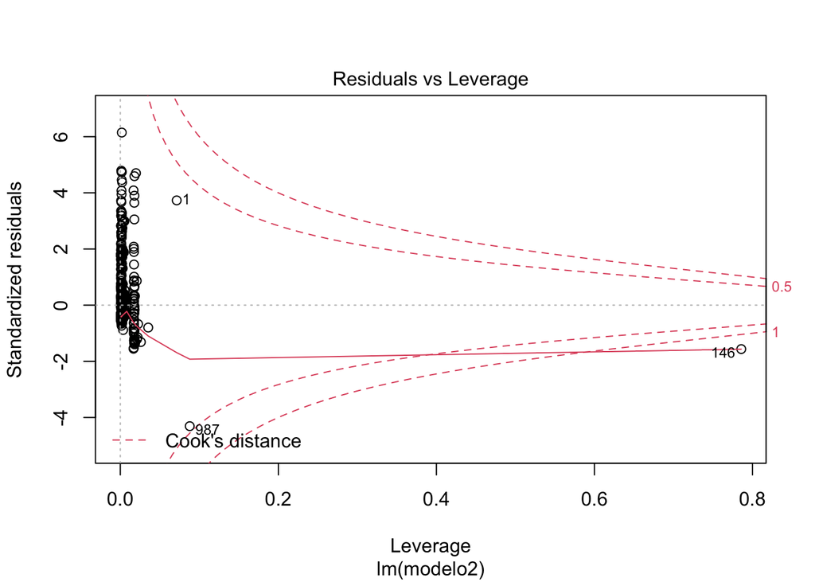

```r
plot(reg2, 5)
```

Asi podemos recuperar los casos influyentes:

```r
checkReg2=as.data.frame(influence.measures(reg2)$is.inf)
head(checkReg2)
```

|  | dfb.1_ | dfb.pctp | dfb.cns1 | dfb.pblc | dffit | cov.r | cook.d | hat |
| --- | --- | --- | --- | --- | --- | --- | --- | --- |
| 1 | FALSE | FALSE | FALSE | TRUE | TRUE | TRUE | FALSE | TRUE |
| 2 | FALSE | FALSE | FALSE | FALSE | FALSE | FALSE | FALSE | FALSE |
| 3 | FALSE | FALSE | FALSE | FALSE | FALSE | FALSE | FALSE | FALSE |
| 4 | FALSE | FALSE | FALSE | FALSE | FALSE | FALSE | FALSE | FALSE |
| 5 | FALSE | FALSE | FALSE | FALSE | FALSE | FALSE | FALSE | FALSE |
| 6 | FALSE | FALSE | FALSE | FALSE | FALSE | FALSE | FALSE | FALSE |

Normalmente le prestamos atencion al indice de Cook y a los valores predecidos (los *hat* values):

```r
checkReg2[checkReg2$cook.d & checkReg2$hat,]
```

|  | dfb.1_ | dfb.pctp | dfb.cns1 | dfb.pblc | dffit | cov.r | cook.d | hat |
| --- | --- | --- | --- | --- | --- | --- | --- | --- |
| 146 | FALSE | FALSE | FALSE | TRUE | TRUE | TRUE | TRUE | TRUE |